# BIO 465 Analysis Exercise 2

Artem Golotin

## Introduction

The goal of this assignment is to help you gain more experience with R. After completing the steps outlined below, please submit the resulting HTML file via Learning Suite. You will be graded on whether you completed all of the analysis steps correctly. If you are unsure on any of the steps, please stop by my office and/or send me an email message.

## Setting your working directory

For part of this exercise, you will be asked to read and write files. When you tell R where to find (or save) a file, you can provide one of two types of file path: absolute or relative. When you specify an *absolute* path, you indicate where on the file system the file is located in relation to the *root* directory (https://en.wikipedia.org/wiki/Root_directory). When you specify a *relative* path, you indicate where on the file system the file is located in relation to the *current* directory. The advantage of using an absolute path is that R will be able to find the file, no matter which directory R is executed in. The advantage of using a relative path is that it is more succinct.

If you want, you can tell R to always look for files in the same directory. This is called your “working directory.” You can change your working directory using a command such as the following.

```r
# setwd("~/Dropbox/Teaching/BIO465/Analysis_Exercises")
```

Write a command to set your working directory to the directory where you have saved this Markdown file.

```r
setwd("~/Desktop/BIO465")
```

## Loading and viewing data

For this exercise, you will analyze a data file that has been provided by GapMinder (http://www.gapminder.org). This file is called “gapminder-FiveYearData.csv” and was included with this assignment.

This comma-delimited file indicates life expectancy and GDP per capita for 142 countries over the past few decades. To analyze the data, you will need to load it into R. R provides various functions that make it possible to read data files. For example, to read a CSV file, you can use the `read.csv` function. (Or you could use `read.table` for a tab-delimited file.)

The following code uses the `read.csv` function to read the “gapminder-FiveYearData.csv file into an object called `data`.

```r
data <- read.csv("gapminder-FiveYearData.csv")
```

This should be a “data frame” object. You can think of this as being similar in concept to an Excel spreadsheet, which contains rows and columns in a grid format. Write command(s) that indicate how many rows and columns this object has. (Refer to the previous assignment, if needed.)

```r
print(dim(data))
```

```
## [1] 1704    6
```

The `str` function provides a brief summary of the “**str**ucture” of the data contained within that object. Please apply this function to the `data` object.

```r
print(str(data))
```

```
## 'data.frame':    1704 obs. of  6 variables:
##  $ country  : Factor w/ 142 levels "Afghanistan",..: 1 1 1 1 1 1 1 1 1 1 ...
##  $ year     : int  1952 1957 1962 1967 1972 1977 1982 1987 1992 1997 ...
##  $ pop      : num  8425333 9240934 10267083 11537966 13079460 ...
##  $ continent: Factor w/ 5 levels "Africa","Americas",..: 3 3 3 3 3 3 3 3 3 3 ...
##  $ lifeExp  : num  28.8 30.3 32 34 36.1 ...
##  $ gdpPercap: num  779 821 853 836 740 ...
## NULL
```

When you have a data frame that contains a large number of rows, you may want to just look at the first few rows to get a better feel for the data. You can use the `head` command for this. Write a command that uses the `head` function to display the first 20 rows of the data. You will need to specify a value for the `n` parameter when calling this function. (Look at the help documentation if needed.)

```r
print(head(data, n = 20))
```

```
##        country year      pop continent lifeExp gdpPercap
## 1  Afghanistan 1952  8425333      Asia  28.801  779.4453
## 2  Afghanistan 1957  9240934      Asia  30.332  820.8530
## 3  Afghanistan 1962 10267083      Asia  31.997  853.1007
## 4  Afghanistan 1967 11537966      Asia  34.020  836.1971
## 5  Afghanistan 1972 13079460      Asia  36.088  739.9811
## 6  Afghanistan 1977 14880372      Asia  38.438  786.1134
## 7  Afghanistan 1982 12881816      Asia  39.854  978.0114
## 8  Afghanistan 1987 13867957      Asia  40.822  852.3959
## 9  Afghanistan 1992 16317921      Asia  41.674  649.3414
## 10 Afghanistan 1997 22227415      Asia  41.763  635.3414
## 11 Afghanistan 2002 25268405      Asia  42.129  726.7341
## 12 Afghanistan 2007 31889923      Asia  43.828  974.5803
## 13     Albania 1952  1282697    Europe  55.230 1601.0561
## 14     Albania 1957  1476505    Europe  59.280 1942.2842
## 15     Albania 1962  1728137    Europe  64.820 2312.8890
## 16     Albania 1967  1984060    Europe  66.220 2760.1969
## 17     Albania 1972  2263554    Europe  67.690 3313.4222
## 18     Albania 1977  2509048    Europe  68.930 3533.0039
## 19     Albania 1982  2780097    Europe  70.420 3630.8807
## 20     Albania 1987  3075321    Europe  72.000 3738.9327
```

The `head` function can be applied to almost any object type in R, including matrices and vectors. There is also a `tail` command that enables you to look at the last few rows of a data frame.

## Working with vectors

You can use the `rownames` and `colnames` functions to retrieve (or set) the row names and column names, respectively, from a data frame. Use the `colnames` function to retrieve the column names for the `data` object and assign them to a variable.

```r
colnames_data <- colnames(data)
```

Write a command that will display the object type for the variable you just created.

```r
print(class(colnames_data))
```

```
## [1] "character"
```

When it says the object type is “character,” that means that it is a one-dimensional vector of values that are all character (string) values.

Write a command that indicates the number of values in this vector. (Hint: use the `length` command.)

```r
print(length(colnames_data))
```

```
## [1] 6
```

Use the `head` function to print the first 3 items in this vector.

```r
print(head(colnames_data, n = 3))
```

```
## [1] "country" "year"    "pop"
```

When working with a data frame, there is a shortcut that can be used to obtain all the values in a specific column. You use the `$` sign for this. For example, if you wanted to obtain all the values in the “country” column, you would enter the following command.

```r
countryVals <- data$country

print(head(countryVals))
```

```
## [1] Afghanistan Afghanistan Afghanistan Afghanistan Afghanistan Afghanistan
## 142 Levels: Afghanistan Albania Algeria Angola Argentina ... Zimbabwe
```

Extract the “lifeExp” column values into a variable called `lifeExpVals` and print the object type of this variable.

```r
lifeExpVals <- data$lifeExp
print(class(lifeExpVals))
```

```
## [1] "numeric"
```

The class of this object should be `numeric`, meaning that it is a vector of numerical values.

### Using the `sapply` function

Another way to work with vector objects is to use the `sapply` function, which enables you to apply a function to each value in a vector. This could be an existing function or an anonymous function. For example, if you wanted to apply the `sqrt` function to each value in a vector, you could do something like the following.

```r
x <- sapply(lifeExpVals, sqrt)

print(head(x))
```

```
## [1] 5.366656 5.507450 5.656589 5.832667 6.007329 6.199839
```

Or if you wanted to do this with an anonymous function, you would do the following.

```r
x <- sapply(lifeExpVals, function(x) { sqrt(x) })

print(head(x))
```

```
## [1] 5.366656 5.507450 5.656589 5.832667 6.007329 6.199839
```

Please note that the previous two examples were for demonstration purposes only. If you wanted to apply the `sqrt` function to a vector of numeric values, a simpler way is shown below. However, in more advanced cases, the `sapply` function does come in handy.

```r
x <- sqrt(lifeExpVals)
```

Practice using the `sapply` function by writing a command that uses an anonymous function to add 5 years to the average life expectancy for each value in the `lifeExpVals` object.

```r
sapply(lifeExpVals, function(x) {x + 5})
```

```
##    [1] 33.80100 35.33200 36.99700 39.02000 41.08800 43.43800 44.85400
##    [8] 45.82200 46.67400 46.76300 47.12900 48.82800 60.23000 64.28000
##   [15] 69.82000 71.22000 72.69000 73.93000 75.42000 77.00000 76.58100
##   [22] 77.95000 80.65100 81.42300 48.07700 50.68500 53.30300 56.40700
##   [29] 59.51800 63.01400 66.36800 70.79900 72.74400 74.15200 75.99400
##   [36] 77.30100 35.01500 36.99900 39.00000 40.98500 42.92800 44.48300
##   [43] 44.94200 44.90600 45.64700 45.96300 46.00300 47.73100 67.48500
##   [50] 69.39900 70.14200 70.63400 72.06500 73.48100 74.94200 75.77400
##   [57] 76.86800 78.27500 79.34000 80.32000 74.12000 75.33000 75.93000
##   [64] 76.10000 76.93000 78.49000 79.74000 81.32000 82.56000 83.83000
##   [71] 85.37000 86.23500 71.80000 72.48000 74.54000 75.14000 75.63000
##   [78] 77.17000 78.18000 79.94000 81.04000 82.51000 83.98000 84.82900
##   [85] 55.93900 58.83200 61.92300 64.92300 68.30000 70.59300 74.05200
##   [92] 75.75000 77.60100 78.92500 79.79500 80.63500 42.48400 44.34800
##   [99] 46.21600 48.45300 50.25200 51.92300 55.00900 57.81900 61.01800
```

[output cut: 229 more lines]

## Working with `factor` objects

Now print the class of the `countryVals` object that was created above.

```r
print(countryVals)
```

```
##    [1] Afghanistan              Afghanistan
##    [3] Afghanistan              Afghanistan
##    [5] Afghanistan              Afghanistan
##    [7] Afghanistan              Afghanistan
##    [9] Afghanistan              Afghanistan
##   [11] Afghanistan              Afghanistan
##   [13] Albania                  Albania
##   [15] Albania                  Albania
##   [17] Albania                  Albania
##   [19] Albania                  Albania
##   [21] Albania                  Albania
##   [23] Albania                  Albania
##   [25] Algeria                  Algeria
##   [27] Algeria                  Algeria
##   [29] Algeria                  Algeria
```

[output cut: 838 more lines]

This is a `factor` object. A factor object is used to represent “discrete” data. Discrete values can contain only a finite number of values. (This is in contrast to numeric or character vectors, which can contain any numeric value or character string, respectively.) In the case of the `` countryVals`` object, it makes sense that it would be a ``factor``` object because there are only a finite number of countries (142 in this data set).

Each possible value in a factor is called a `level`. One way to summarize a `factor` object is to use the `table` function. It indicates how many values are present for each level. Apply the `table` function to the `countryVals` object.

```r
table(countryVals)
```

```
## countryVals
##              Afghanistan                  Albania                  Algeria
##                       12                       12                       12
##                   Angola                Argentina                Australia
##                       12                       12                       12
##                  Austria                  Bahrain               Bangladesh
##                       12                       12                       12
##                  Belgium                    Benin                  Bolivia
##                       12                       12                       12
##   Bosnia and Herzegovina                 Botswana                   Brazil
##                       12                       12                       12
##                 Bulgaria             Burkina Faso                  Burundi
##                       12                       12                       12
##                 Cambodia                 Cameroon                   Canada
##                       12                       12                       12
## Central African Republic                     Chad                    Chile
##                       12                       12                       12
##                    China                 Colombia                  Comoros
##                       12                       12                       12
##          Congo Dem. Rep.               Congo Rep.               Costa Rica
##                       12                       12                       12
##            Cote d'Ivoire                  Croatia                     Cuba
##                       12                       12                       12
##           Czech Republic                  Denmark                 Djibouti
##                       12                       12                       12
##       Dominican Republic                  Ecuador                    Egypt
##                       12                       12                       12
##              El Salvador        Equatorial Guinea                  Eritrea
##                       12                       12                       12
##                 Ethiopia                  Finland                   France
##                       12                       12                       12
##                    Gabon                   Gambia                  Germany
##                       12                       12                       12
##                    Ghana                   Greece                Guatemala
##                       12                       12                       12
##                   Guinea            Guinea-Bissau                    Haiti
##                       12                       12                       12
##                 Honduras          Hong Kong China                  Hungary
##                       12                       12                       12
##                  Iceland                    India                Indonesia
```

[output cut: 42 more lines]

```
##                       12                       12                       12
##              Switzerland                    Syria                   Taiwan
##                       12                       12                       12
##                 Tanzania                 Thailand                     Togo
##                       12                       12                       12
##      Trinidad and Tobago                  Tunisia                   Turkey
##                       12                       12                       12
##                   Uganda           United Kingdom            United States
##                       12                       12                       12
##                  Uruguay                Venezuela                  Vietnam
##                       12                       12                       12
##       West Bank and Gaza               Yemen Rep.                   Zambia
##                       12                       12                       12
##                 Zimbabwe
##                       12
```

This should have indicated that there are 12 values for each country.

You can apply many R functions to the output of `table`. For example, if you wanted to know the maximum number of data values that were present for any country, you could use the following command.

```r
max(table(countryVals))
```

```
## [1] 12
```

## Subsetting data frames

Now suppose you wanted to obtain all the rows in the `data` object that represented Afghanistan. You could use the `which` function for this. If you apply the `which` function to the “country” column, it will tell you the index of each row that is “Afghanistan.” For example:

```r
afghIndices <- which(data$country=="Afghanistan")

print(afghIndices)
```

```
##  [1]  1  2  3  4  5  6  7  8  9 10 11 12
```

You could then obtain these rows from the `data` object using the following command:

```r
afghData <- data[afghIndices,]

print(afghData)
```

```
##        country year      pop continent lifeExp gdpPercap
## 1  Afghanistan 1952  8425333      Asia  28.801  779.4453
## 2  Afghanistan 1957  9240934      Asia  30.332  820.8530
## 3  Afghanistan 1962 10267083      Asia  31.997  853.1007
## 4  Afghanistan 1967 11537966      Asia  34.020  836.1971
## 5  Afghanistan 1972 13079460      Asia  36.088  739.9811
## 6  Afghanistan 1977 14880372      Asia  38.438  786.1134
## 7  Afghanistan 1982 12881816      Asia  39.854  978.0114
## 8  Afghanistan 1987 13867957      Asia  40.822  852.3959
## 9  Afghanistan 1992 16317921      Asia  41.674  649.3414
## 10 Afghanistan 1997 22227415      Asia  41.763  635.3414
## 11 Afghanistan 2002 25268405      Asia  42.129  726.7341
## 12 Afghanistan 2007 31889923      Asia  43.828  974.5803
```

Now create an object that contains data for the United States only. Call this object `usData`.

```r
usData <- data[which(data$country=="United States"),]
```

## Merging data frames

When you have two data frame objects, you can merge them easily in R. For example, if you wanted to combine the Afghanistan data with the United States data, you could use the `rbind` function.

```r
rbind(afghData, usData)
```

```
##            country year       pop continent lifeExp  gdpPercap
## 1      Afghanistan 1952   8425333      Asia  28.801   779.4453
## 2      Afghanistan 1957   9240934      Asia  30.332   820.8530
## 3      Afghanistan 1962  10267083      Asia  31.997   853.1007
## 4      Afghanistan 1967  11537966      Asia  34.020   836.1971
## 5      Afghanistan 1972  13079460      Asia  36.088   739.9811
## 6      Afghanistan 1977  14880372      Asia  38.438   786.1134
## 7      Afghanistan 1982  12881816      Asia  39.854   978.0114
## 8      Afghanistan 1987  13867957      Asia  40.822   852.3959
## 9      Afghanistan 1992  16317921      Asia  41.674   649.3414
## 10     Afghanistan 1997  22227415      Asia  41.763   635.3414
## 11     Afghanistan 2002  25268405      Asia  42.129   726.7341
## 12     Afghanistan 2007  31889923      Asia  43.828   974.5803
## 1609 United States 1952 157553000  Americas  68.440 13990.4821
## 1610 United States 1957 171984000  Americas  69.490 14847.1271
## 1611 United States 1962 186538000  Americas  70.210 16173.1459
## 1612 United States 1967 198712000  Americas  70.760 19530.3656
## 1613 United States 1972 209896000  Americas  71.340 21806.0359
## 1614 United States 1977 220239000  Americas  73.380 24072.6321
## 1615 United States 1982 232187835  Americas  74.650 25009.5591
## 1616 United States 1987 242803533  Americas  75.020 29884.3504
## 1617 United States 1992 256894189  Americas  76.090 32003.9322
## 1618 United States 1997 272911760  Americas  76.810 35767.4330
## 1619 United States 2002 287675526  Americas  77.310 39097.0995
## 1620 United States 2007 301139947  Americas  78.242 42951.6531
```

There is also a `cbind` that you can used to “bind” two data frames by column (horizontally) rather than by row (vertically). For example:

```r
cbind(afghData, usData)
```

```
##        country year      pop continent lifeExp gdpPercap       country
## 1  Afghanistan 1952  8425333      Asia  28.801  779.4453 United States
## 2  Afghanistan 1957  9240934      Asia  30.332  820.8530 United States
## 3  Afghanistan 1962 10267083      Asia  31.997  853.1007 United States
## 4  Afghanistan 1967 11537966      Asia  34.020  836.1971 United States
## 5  Afghanistan 1972 13079460      Asia  36.088  739.9811 United States
## 6  Afghanistan 1977 14880372      Asia  38.438  786.1134 United States
## 7  Afghanistan 1982 12881816      Asia  39.854  978.0114 United States
## 8  Afghanistan 1987 13867957      Asia  40.822  852.3959 United States
## 9  Afghanistan 1992 16317921      Asia  41.674  649.3414 United States
## 10 Afghanistan 1997 22227415      Asia  41.763  635.3414 United States
## 11 Afghanistan 2002 25268405      Asia  42.129  726.7341 United States
## 12 Afghanistan 2007 31889923      Asia  43.828  974.5803 United States
##    year       pop continent lifeExp gdpPercap
## 1  1952 157553000  Americas  68.440  13990.48
## 2  1957 171984000  Americas  69.490  14847.13
## 3  1962 186538000  Americas  70.210  16173.15
## 4  1967 198712000  Americas  70.760  19530.37
## 5  1972 209896000  Americas  71.340  21806.04
## 6  1977 220239000  Americas  73.380  24072.63
## 7  1982 232187835  Americas  74.650  25009.56
## 8  1987 242803533  Americas  75.020  29884.35
## 9  1992 256894189  Americas  76.090  32003.93
## 10 1997 272911760  Americas  76.810  35767.43
## 11 2002 287675526  Americas  77.310  39097.10
## 12 2007 301139947  Americas  78.242  42951.65
```

There are more advanced ways to do these types of operations, but we’ll wait until a later exercise to go through these.

## Working with `matrix` objects

A data frame is similar in shape (2-dimensional) to a matrix. A key difference between these two object types is that a matrix can contain only one type of object (typically numeric values). If you tried to put two types of object into the same matrix, it would convert all the values to the more generic object type. For example, if you put character/string and integer objects in a matrix, it would convert all the values to character/string values, as demonstrated below.

```r
head(as.matrix(data))
```

```
##      country       year   pop          continent lifeExp    gdpPercap
## [1,] "Afghanistan" "1952" "   8425333" "Asia"    "28.80100" "   779.4453"
## [2,] "Afghanistan" "1957" "   9240934" "Asia"    "30.33200" "   820.8530"
## [3,] "Afghanistan" "1962" "  10267083" "Asia"    "31.99700" "   853.1007"
## [4,] "Afghanistan" "1967" "  11537966" "Asia"    "34.02000" "   836.1971"
## [5,] "Afghanistan" "1972" "  13079460" "Asia"    "36.08800" "   739.9811"
## [6,] "Afghanistan" "1977" "  14880372" "Asia"    "38.43800" "   786.1134"
```

Notice that each of the values is surrounded by quotation marks, which indicate these these are character values.

Let’s create a matrix object that contains only the 5th and 6th columns of the data frame. These two columns contain only numerical data. With either a matrix or a data frame, we can extract specific columns (or rows) by specifying their indices rather than their names. The following code extracts the first 48 rows and the 5th and 6th columns.

```r
matrixData <- data[1:48,5:6]

print(head(matrixData))
```

```
##   lifeExp gdpPercap
## 1  28.801  779.4453
## 2  30.332  820.8530
## 3  31.997  853.1007
## 4  34.020  836.1971
## 5  36.088  739.9811
## 6  38.438  786.1134
```

Notice that all the values are numeric (none of them is surrounded by quotation marks).

Let’s create a new variable that contains the country name for the first 48 rows.

```r
# Extract the first 48 values
countryValuesFirst48 <- countryVals[1:48]

print(countryValuesFirst48)
```

```
##  [1] Afghanistan Afghanistan Afghanistan Afghanistan Afghanistan
##  [6] Afghanistan Afghanistan Afghanistan Afghanistan Afghanistan
## [11] Afghanistan Afghanistan Albania     Albania     Albania
## [16] Albania     Albania     Albania     Albania     Albania
## [21] Albania     Albania     Albania     Albania     Algeria
## [26] Algeria     Algeria     Algeria     Algeria     Algeria
## [31] Algeria     Algeria     Algeria     Algeria     Algeria
## [36] Algeria     Angola      Angola      Angola      Angola
## [41] Angola      Angola      Angola      Angola      Angola
## [46] Angola      Angola      Angola
## 142 Levels: Afghanistan Albania Algeria Angola Argentina ... Zimbabwe
```

Notice that when we print this object, it contains the country name for the first 48 rows. However, because it is a factor object, it contains “levels” for all 142 countries that were listed in the full data set. So let’s convert it to a character vector so it will “forget” the levels.

```r
countryValuesFirst48 <- as.character(countryValuesFirst48)

print(countryValuesFirst48)
```

```
##  [1] "Afghanistan" "Afghanistan" "Afghanistan" "Afghanistan" "Afghanistan"
##  [6] "Afghanistan" "Afghanistan" "Afghanistan" "Afghanistan" "Afghanistan"
## [11] "Afghanistan" "Afghanistan" "Albania"     "Albania"     "Albania"
## [16] "Albania"     "Albania"     "Albania"     "Albania"     "Albania"
## [21] "Albania"     "Albania"     "Albania"     "Albania"     "Algeria"
## [26] "Algeria"     "Algeria"     "Algeria"     "Algeria"     "Algeria"
## [31] "Algeria"     "Algeria"     "Algeria"     "Algeria"     "Algeria"
## [36] "Algeria"     "Angola"      "Angola"      "Angola"      "Angola"
## [41] "Angola"      "Angola"      "Angola"      "Angola"      "Angola"
## [46] "Angola"      "Angola"      "Angola"
```

Now we can convert it back to a factor object. This object will only contain 4 levels.

```r
countryValsFirst48 <- as.factor(countryValuesFirst48)

print(countryValsFirst48)
```

```
##  [1] Afghanistan Afghanistan Afghanistan Afghanistan Afghanistan
##  [6] Afghanistan Afghanistan Afghanistan Afghanistan Afghanistan
## [11] Afghanistan Afghanistan Albania     Albania     Albania
## [16] Albania     Albania     Albania     Albania     Albania
## [21] Albania     Albania     Albania     Albania     Algeria
## [26] Algeria     Algeria     Algeria     Algeria     Algeria
## [31] Algeria     Algeria     Algeria     Algeria     Algeria
## [36] Algeria     Angola      Angola      Angola      Angola
## [41] Angola      Angola      Angola      Angola      Angola
## [46] Angola      Angola      Angola
## Levels: Afghanistan Albania Algeria Angola
```

## Creating box and whisker plots

One way we can use the `countryValsFirst48` factor object is to create a “box and whisker” plot of the data. For example, we can see how life expectancy varies by country. To do this, we will use the `boxplot` function and specify a formula. Formulas in R typically use the `~` character to indicate the relationship between two variables. Below is an example. (Click on the “Zoom” button in RStudio if needed to see the full figure.)

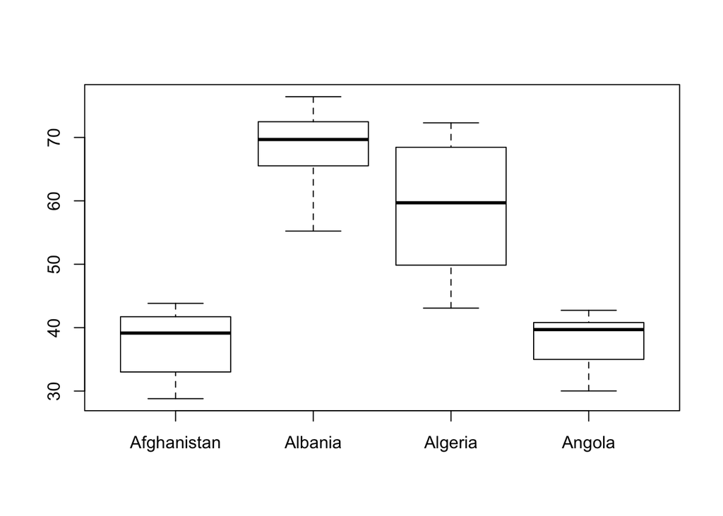

```r
boxplot(matrixData$lifeExp ~ countryValsFirst48)
```

Which of these four countries has the highest average life expectancy?

#### Albania

Now create a boxplot that shows the relationship between country and GDP per capita for these four countries.

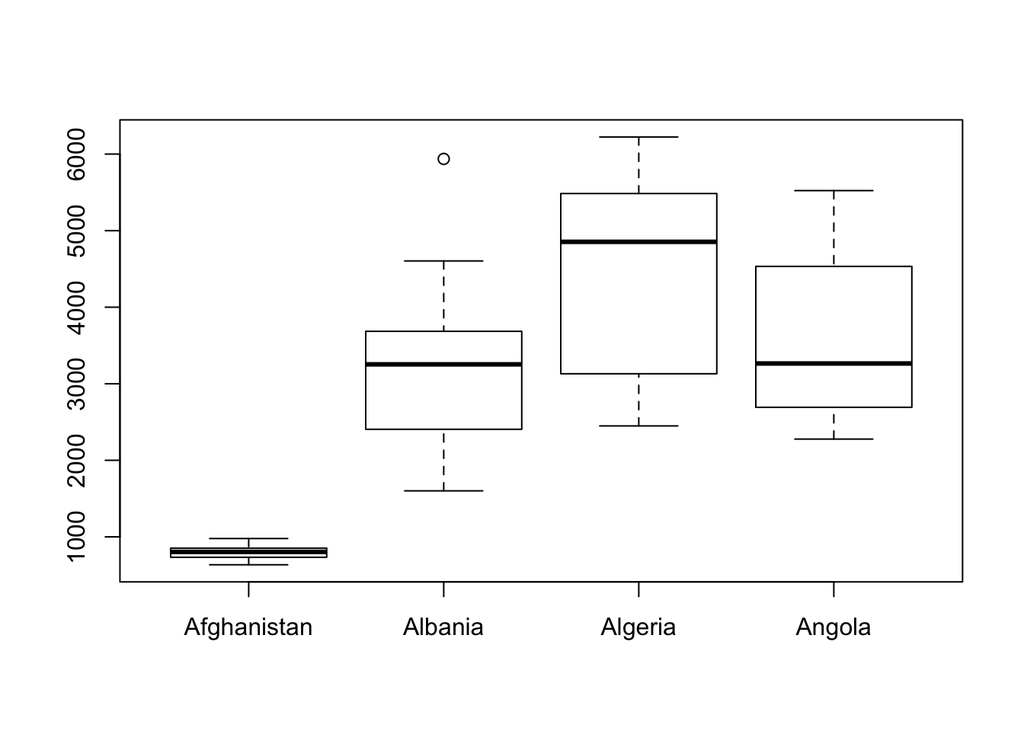

```r
boxplot(matrixData$gdpPercap ~ countryValsFirst48)
```

Which of these four countries has the highest GDP per capita?

## Working with the `apply` function

When working with 2-dimensional objects (such as matrices and data frames), you can use the `apply` function to apply a function either to 1) all the rows of the object or 2) to all of the columns. For example, the following code would calculate the median value for both columns in the `matrixData` object.

```r
columnMedians <- apply(matrixData, 2, median)

print(columnMedians)
```

```
##   lifeExp gdpPercap
##   43.4525 2890.9673
```

The second parameter in the `apply` function is a value of `2`. This is because R uses `1` to represent rows and `2` to represent columns. If we wanted to apply the median function to each row, we would do the following.

```r
rowMedians <- apply(matrixData, 1, median)
```

After completing the steps requested above, knit this document and submit the resulting HTML file via Learning Suite.